# Advanced Empirical Finance: Topics and Data Science

From predictions to implementable portfolios

Stefan Voigt

University of Copenhagen and Danish Finance Institute (DFI)

Spring 2027

## Today

- Assignment 2 discussion (first hour)
- Your scoreboard
- What the portfolios trade
- After costs: the implementable efficient frontier

# Assignment 2 discussion

# Your scoreboard

## Can you beat the scoreboard?

# What the portfolios trade

## Turnover

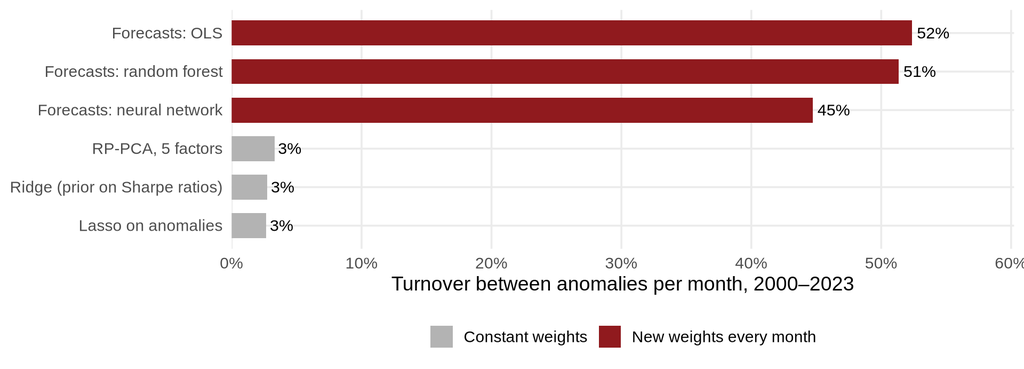

- **Between anomalies:** weights scaled to a gross position of 1. Constant SDF weights only trade back after the anomalies drift; forecasts change the weights every month
- **Inside each anomaly:** every long-short portfolio is itself rebalanced. Our returns are before these costs. For comparison, the decile portfolios of Gu, Kelly & Xiu turn over 111% to 152% of their value a month with machine learning forecasts, 58% with OLS-3 (value-weighted, their Table 8)

## The implementable efficient frontier

- **Jensen, Kelly, Malamud & Pedersen:** judge a strategy by its return **after trading costs** at each level of risk, the *implementable efficient frontier*
- Forecasts that ignore costs lean on short-lived characteristics: what looks best before costs trades the most
- Better: learn the **portfolio weights** directly, with the trading costs in the objective. The same idea as the cost-aware weights of lecture 5, now with machine learning
- *Economic feature importance:* which characteristics still matter after costs

## Scoreboard of the machine learning lectures

[output not shown]

- The trading game charges 10 bps of every trade since 1 March: your own record is a row of this scoreboard